# R for Data Science Chapter 1: Data Visualisation

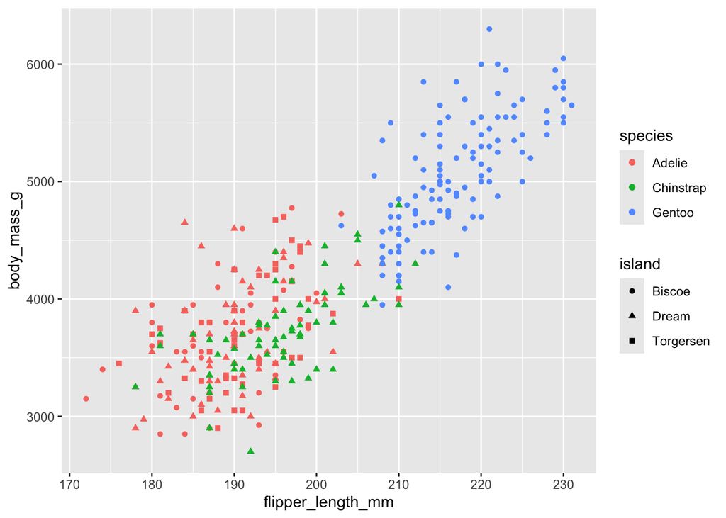

```r
ggplot(penguins, aes(x = flipper_length_mm, y = body_mass_g)) +
  geom_point(aes(color = species, shape = island))
```

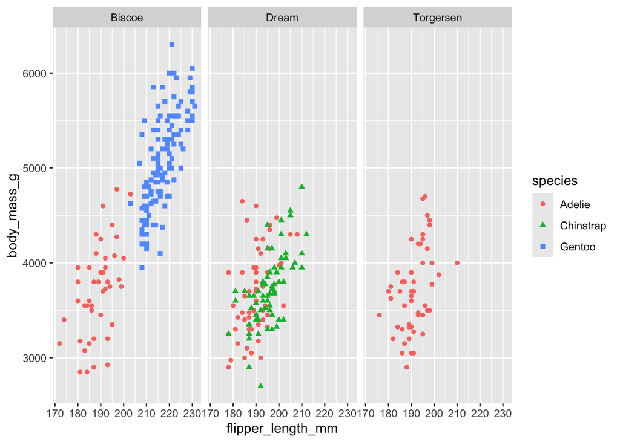

```r
ggplot(penguins, aes(x = flipper_length_mm, y = body_mass_g)) +
  geom_point(aes(color = species, shape = species)) +
  facet_wrap(~island)
```

### 9 Exercises

#### 9.1 The mpg data frame that is bundled with the ggplot2 package contains 234 observations collected by the US Environmental Protection Agency on 38 car models. Which variables in mpg are categorical? Which variables are numerical? (Hint: Type ?mpg to read the documentation for the dataset.) How can you see this information when you run mpg?

```r
mpg
```

```
## # A tibble: 234 × 11
##    manufacturer model      displ  year   cyl trans drv     cty   hwy fl    class
##    <chr>        <chr>      <dbl> <int> <int> <chr> <chr> <int> <int> <chr> <chr>
##  1 audi         a4           1.8  1999     4 auto… f        18    29 p     comp…
##  2 audi         a4           1.8  1999     4 manu… f        21    29 p     comp…
##  3 audi         a4           2    2008     4 manu… f        20    31 p     comp…
##  4 audi         a4           2    2008     4 auto… f        21    30 p     comp…
##  5 audi         a4           2.8  1999     6 auto… f        16    26 p     comp…
##  6 audi         a4           2.8  1999     6 manu… f        18    26 p     comp…
##  7 audi         a4           3.1  2008     6 auto… f        18    27 p     comp…
##  8 audi         a4 quattro   1.8  1999     4 manu… 4        18    26 p     comp…
##  9 audi         a4 quattro   1.8  1999     4 auto… 4        16    25 p     comp…
## 10 audi         a4 quattro   2    2008     4 manu… 4        20    28 p     comp…
## # ℹ 224 more rows
```

```r
glimpse(mpg)
```

```
## Rows: 234
## Columns: 11
## $ manufacturer <chr> "audi", "audi", "audi", "audi", "audi", "audi", "audi", "…
## $ model        <chr> "a4", "a4", "a4", "a4", "a4", "a4", "a4", "a4 quattro", "…
## $ displ        <dbl> 1.8, 1.8, 2.0, 2.0, 2.8, 2.8, 3.1, 1.8, 1.8, 2.0, 2.0, 2.…
## $ year         <int> 1999, 1999, 2008, 2008, 1999, 1999, 2008, 1999, 1999, 200…
## $ cyl          <int> 4, 4, 4, 4, 6, 6, 6, 4, 4, 4, 4, 6, 6, 6, 6, 6, 6, 8, 8, …
## $ trans        <chr> "auto(l5)", "manual(m5)", "manual(m6)", "auto(av)", "auto…
## $ drv          <chr> "f", "f", "f", "f", "f", "f", "f", "4", "4", "4", "4", "4…
## $ cty          <int> 18, 21, 20, 21, 16, 18, 18, 18, 16, 20, 19, 15, 17, 17, 1…
## $ hwy          <int> 29, 29, 31, 30, 26, 26, 27, 26, 25, 28, 27, 25, 25, 25, 2…
## $ fl           <chr> "p", "p", "p", "p", "p", "p", "p", "p", "p", "p", "p", "p…
## $ class        <chr> "compact", "compact", "compact", "compact", "compact", "c…
```

Categorical: manufacturer, model, trans, drv, fl, class  
Numerical: displ, year, cyl,cty, hwy

#### 9.2 Make a scatterplot of hwy vs. displ using the mpg data frame. Next, map a third, numerical variable to color, then size, then both color and size, then shape. How do these aesthetics behave differently for categorical vs. numerical variables?

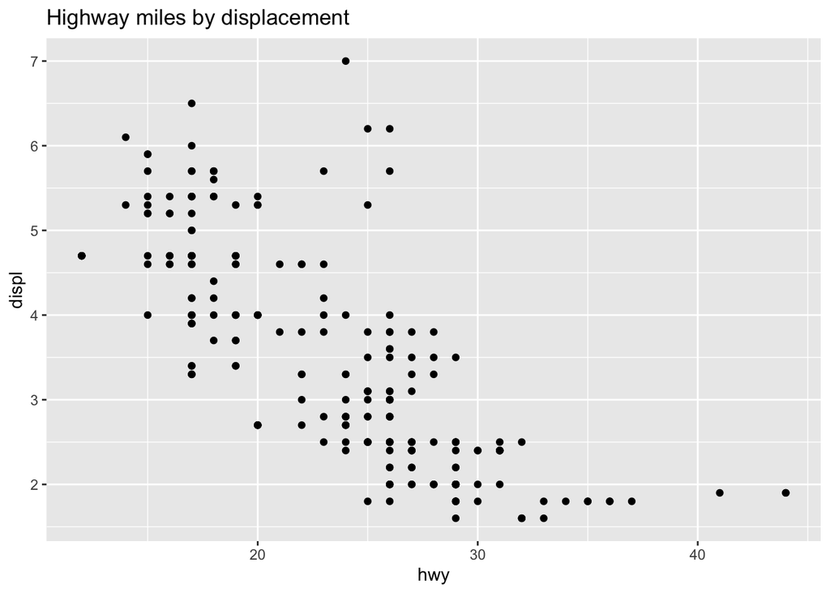

```r
ggplot(mpg, aes(x = hwy, y = displ)) +
  geom_point() +
  labs(title = "Highway miles by displacement")
```

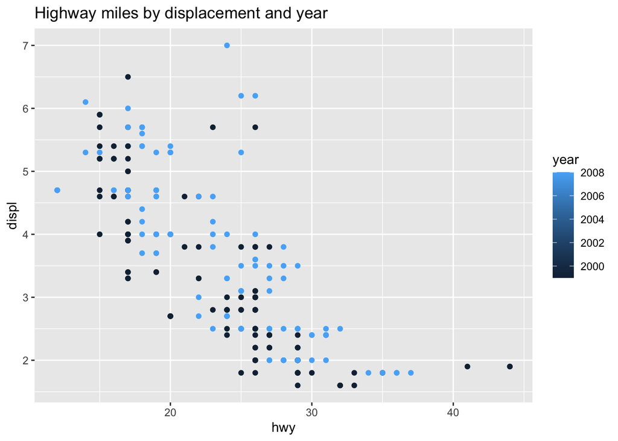

```r
ggplot(mpg, aes(x = hwy, y = displ)) +
  geom_point(aes(colour = year)) +
  labs(title = "Highway miles by displacement and year")
```

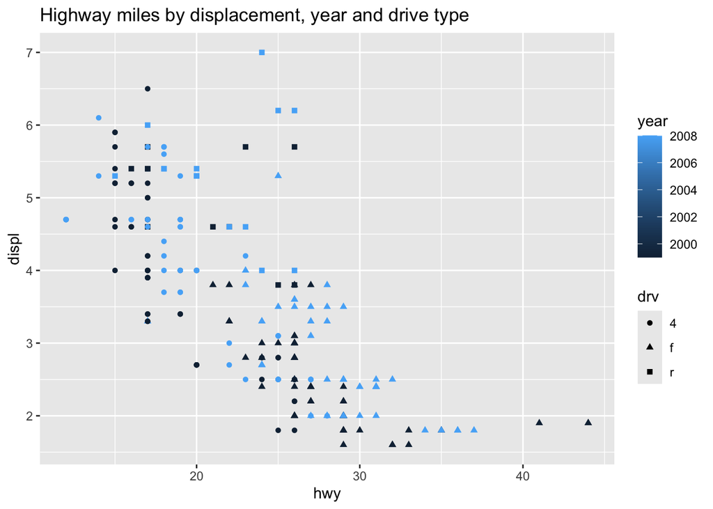

```r
ggplot(mpg, aes(x = hwy, y = displ)) +
  geom_point(aes(color = year, shape = drv)) +
  labs(title = "Highway miles by displacement, year and drive type")
```

The aesthetics behave differently with the x and y variables being mapped on their corrosponding axis while color changes the colour of the observation based on its numerical value. For example, a car made in 2008 is a light blue colour and the colour gets darker as the car ages. The shape reflects the drive train of the car so it’s easier to find either category.

#### 9.3 In the scatterplot of hwy vs. displ, what happens if you map a third variable to linewidth?

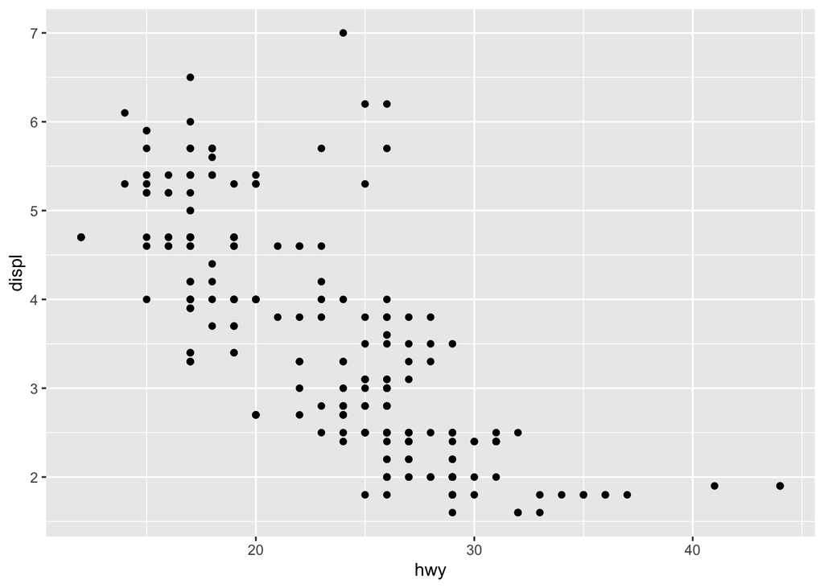

```r
ggplot(mpg, aes(x = hwy, y = displ, linewidth = cty)) +
  geom_point()
```

Linewidth is ignored.

#### 9.4 What happens if you map the same variable to multiple aesthetics?

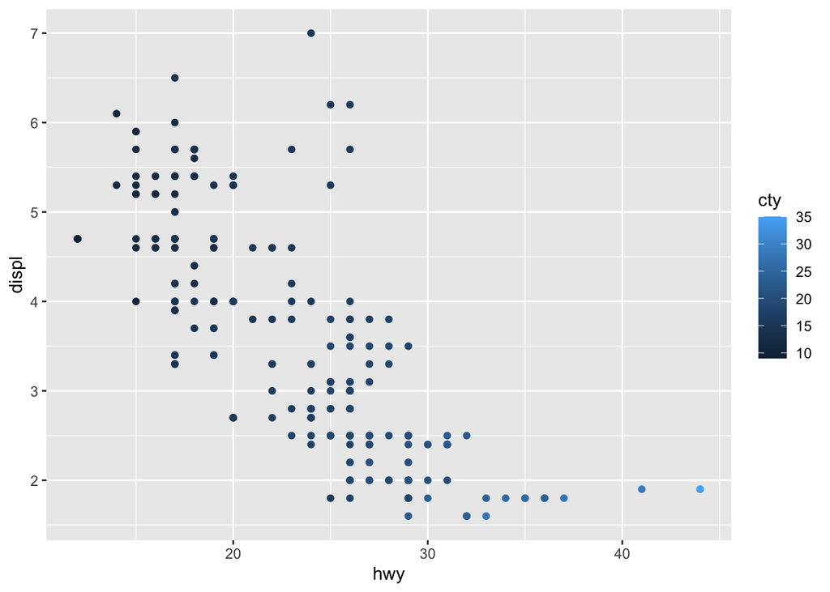

```r
ggplot(mpg, aes(x = hwy, y = displ)) +
  geom_point(aes(colour = cty))
```

The cty variable is now added into the plot as a colour.

#### 9.5 Make a scatterplot of bill_depth_mm vs. bill_length_mm and color the points by species. What does adding coloring by species reveal about the relationship between these two variables? What about faceting by species?

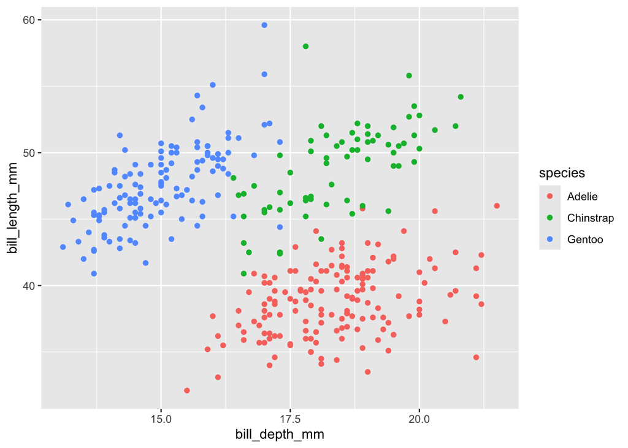

```r
ggplot(penguins, aes(x = bill_depth_mm, y = bill_length_mm, colour = species)) +
  geom_point()
```

#### 9.6 Why does the following yield two separate legends? How would you fix it to combine the two legends?

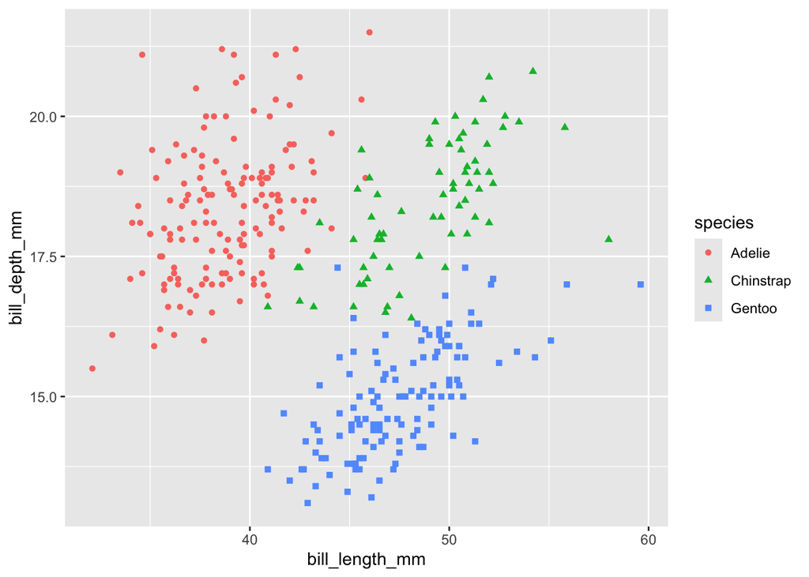

```r
ggplot(
  data = penguins,
  mapping = aes(
    x = bill_length_mm, y = bill_depth_mm,
    color = species, shape = species
  )
) +
  geom_point()
```

To fix this visualisation, I removed the additional lavel which was present in the end part of the code. This was creating a duplicate of the legend.